# Статистика стран и их основных характеристик

Valery Andruynichev

16 nov 2017 year

В данной работе представлена статистика стран и их основных характеристик.

I. Для выполнения работы потребуются следующие пакеты:

```r
library(ggplot2)
library(reshape2)
library(dplyr)
library(nortest)
library(moments)
```

2. Данные для анализа использованны данные Всемирного Банка(World Bank)

Загрузка файла с данными Указание пути к папке, где лежит файл с данными

```r
dir<-"D://GH//Country//"
```

Загрузка файла

```r
wb<-read.csv(paste(dir,'wb_econometrics.csv',sep=''),stringsAsFactors = FALSE)
```

Для простоты рабы с фалом перобразуем его в вертикальный формат

```r
wb<-melt(wb,id=colnames(wb)[1:4])
colnames(wb)[5]<-'Year'
wb$Year<-as.numeric(gsub('X','',as.character(wb$Year)))
```

3. Рассмотрим полученные данные:
1. Перечень стран

```r
unique(wb$Country.name)
```

```
##   [1] "Aruba"                          "Afghanistan"
##   [3] "Angola"                         "Albania"
##   [5] "Andorra"                        "United Arab Emirates"
##   [7] "Argentina"                      "Armenia"
##   [9] "American Samoa"                 "Antigua and Barbuda"
##  [11] "Australia"                      "Austria"
##  [13] "Azerbaijan"                     "Burundi"
##  [15] "Belgium"                        "Benin"
##  [17] "Burkina Faso"                   "Bangladesh"
##  [19] "Bulgaria"                       "Bahrain"
##  [21] "Bahamas, The"                   "Bosnia and Herzegovina"
##  [23] "Belarus"                        "Belize"
##  [25] "Bermuda"                        "Bolivia"
##  [27] "Brazil"                         "Barbados"
##  [29] "Brunei Darussalam"              "Bhutan"
```

[output cut: 93 more lines]

2. Перечень индикаторов

```r
unique(wb$Indicator.Name)
```

```
##  [1] "Adjusted savings: energy depletion (% of GNI)"
##  [2] "Adjusted savings: energy depletion (current US$)"
##  [3] "Agriculture, value added (% of GDP)"
##  [4] "Alternative and nuclear energy (% of total energy use)"
##  [5] "Broad money (% of GDP)"
##  [6] "Central government debt, total (% of GDP)"
##  [7] "Claims on other sectors of the domestic economy (% of GDP)"
##  [8] "CO2 intensity (kg per kg of oil equivalent energy use)"
##  [9] "Coal rents (% of GDP)"
## [10] "Combustible renewables and waste (% of total energy)"
## [11] "Current account balance (% of GDP)"
## [12] "Domestic credit provided by financial sector (% of GDP)"
## [13] "Domestic credit to private sector (% of GDP)"
## [14] "Domestic credit to private sector by banks (% of GDP)"
## [15] "Energy imports, net (% of energy use)"
```

[output cut: 65 more lines]

Сумма пустых(NA) наблюдений по определенному индикатору на определенный год

```r
sum(is.na(wb%>%filter(Year==2016,Indicator.Name=='GDP per capita (current US$)')%>%select(value)))
```

```
## [1] 35
```

4. Построим и визуализируем данные по определенным показателям для выбранных стран за определенный период времени

```r
countries<-c("United States","Norway","Japan","China","Kazakhstan","Russian Federation")
```

И выберем индикаторы: Рост ВВП (в %), ВВП на душу населения (в $ по курсу на выбранный год), Доходы от продажи нефти (в % от ВВП), Налоговые поступления (в % от ВВП)

```r
indicator<-c("GDP growth (annual %)",'GDP per capita (current US$)',"Oil rents (% of GDP)","Tax revenue (% of GDP)")
```

Создадим модель

```r
wb%>%filter((Country.name %in% countries)&(Indicator.Name %in% indicator)            &Year>2014&Year<2016)%>%select(Country.name,Indicator.Name,Year,value)
```

```
##          Country.name               Indicator.Name Year         value
## 1               China        GDP growth (annual %) 2015  6.900205e+00
## 2               China GDP per capita (current US$) 2015  8.069212e+03
## 3               China         Oil rents (% of GDP) 2015  2.528305e-01
## 4               China       Tax revenue (% of GDP) 2015            NA
## 5               Japan        GDP growth (annual %) 2015  1.219438e+00
## 6               Japan GDP per capita (current US$) 2015  3.447414e+04
## 7               Japan         Oil rents (% of GDP) 2015  6.199774e-04
## 8               Japan       Tax revenue (% of GDP) 2015  1.144025e+01
## 9          Kazakhstan        GDP growth (annual %) 2015  1.200000e+00
## 10         Kazakhstan GDP per capita (current US$) 2015  1.050998e+04
## 11         Kazakhstan         Oil rents (% of GDP) 2015  5.632175e+00
## 12         Kazakhstan       Tax revenue (% of GDP) 2015  9.835712e+00
## 13             Norway        GDP growth (annual %) 2015  1.611027e+00
## 14             Norway GDP per capita (current US$) 2015  7.450525e+04
## 15             Norway         Oil rents (% of GDP) 2015  3.043253e+00
## 16             Norway       Tax revenue (% of GDP) 2015  2.244523e+01
## 17 Russian Federation        GDP growth (annual %) 2015 -2.828241e+00
## 18 Russian Federation GDP per capita (current US$) 2015  9.329298e+03
## 19 Russian Federation         Oil rents (% of GDP) 2015  5.579337e+00
## 20 Russian Federation       Tax revenue (% of GDP) 2015  1.062353e+01
## 21      United States        GDP growth (annual %) 2015  2.596148e+00
## 22      United States GDP per capita (current US$) 2015  5.620704e+04
## 23      United States         Oil rents (% of GDP) 2015  4.912636e-02
## 24      United States       Tax revenue (% of GDP) 2015  1.141580e+01
```

В полученной таблицы мы видим выбраные нами страны и их показатели за требуемый год.

V.Создадим модель времяного ряда по доходам от продажи нефти (в % от ВВП) для Росии с 1988г.

Создадим выборку данных из основного файла

```r
rus_growth<-wb%>%filter(Country.name=="Russian Federation",Indicator.Name=="Oil rents (% of GDP)",
                        Year>1988)%>%dplyr::select(Year,value)
rus_growth
```

```
##    Year     value
## 1  1989  7.751280
## 2  1990  9.777851
## 3  1991  4.097889
## 4  1992  3.831800
## 5  1993  3.711690
## 6  1994  3.426575
## 7  1995  4.069573
## 8  1996  5.575469
## 9  1997  4.307831
## 10 1998  1.342632
## 11 1999  7.537612
## 12 2000 14.254786
## 13 2001  9.545177
## 14 2002  9.700800
## 15 2003 10.302694
## 16 2004 11.171627
## 17 2005 13.552414
## 18 2006 12.726617
## 19 2007 10.444949
## 20 2008 11.219835
## 21 2009  8.122096
## 22 2010  9.529575
## 23 2011 11.085839
## 24 2012 10.265145
## 25 2013  9.156884
## 26 2014  8.835491
## 27 2015  5.579337
## 28 2016        NA
```

Визуализируем дааные по России

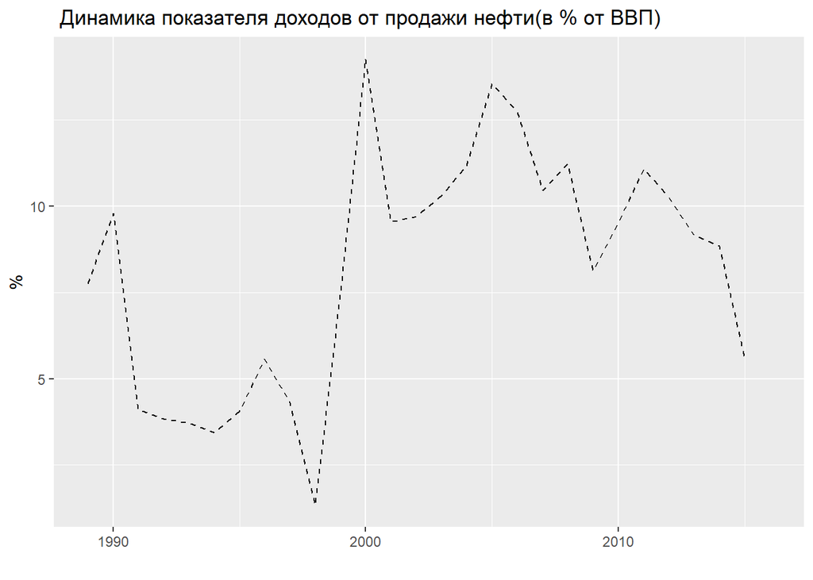

```r
ggplot(data=rus_growth,aes(Year,value))+geom_line(linetype = "dashed")+xlab('')+ylab('%')+
  ggtitle(' Динамика показателя доходов от продажи нефти(в % от ВВП)')
```

По графику видно, что с 1998 по 200 годы был стремительный рост доходов от продажи нефти, после 2000 годов последовао боковое движение и после 2012 постоянный спад доходов от продажи нефти.

6. Создадим набор данных стран по доходам от продажи нефти pf 2015 год, и ранжируем их по уменьшению этих доходов. Анализируем только 20 стран с самым большими доходами от продажи нефти

```r
df<-head(wb%>%filter
(Year==2015&Indicator.Name=="Oil rents (% of GDP)")%>%
arrange(desc(value)),20)
```

И визуализируем данные

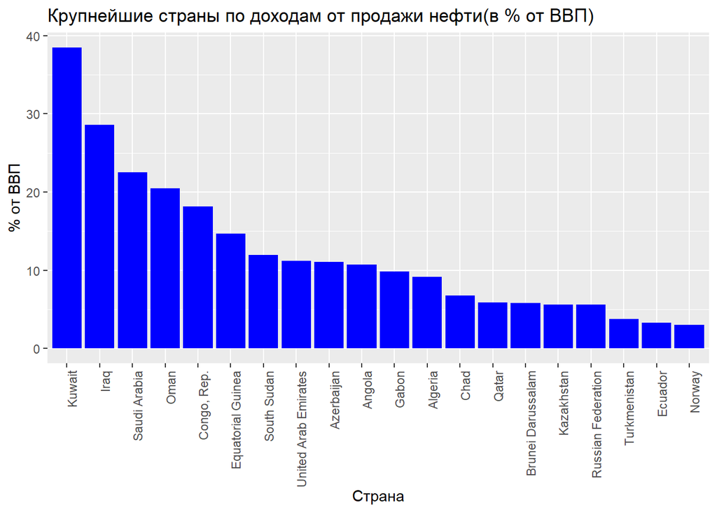

```r
ggplot(data=df,aes(reorder(Country.name,value,desc),value))+geom_bar(stat = "identity",fill = "blue")+
  xlab('Страна')+ylab('% от ВВП')+ggtitle('Крупнейшие страны по доходам от продажи нефти(в % от ВВП) ')+
  theme(axis.text.x = element_text(angle = 90, hjust = 1))
```

По гистограмме видно, что самый большой доход у Кювейта 38,5%. Россия занимает 17-е масто в данном списке с результатом 5,6%

7. Статистический анализ показателя: доходы от продажи нефти (в % от ВВП)

Создадим вспомагательную переменнуюотчищеную от пустых(NA) значений

```r
x<-na.omit(wb%>%filter(Year==2015,Indicator.Name=="Oil rents (% of GDP)")%>%dplyr::select(value))$value
```

Основные статистические показатели

```r
summary(x)
```

```
##     Min.  1st Qu.   Median     Mean  3rd Qu.     Max.
##  0.00000  0.00000  0.06179  2.17078  1.31941 38.48251
```

Оценим коэффициенты асимметрии дохода от продажи нефти (в % от ВВП)

```r
skewness(x)
```

```
## [1] 3.931559
```

И эксцесса

```r
kurtosis(x)
```

```
## [1] 20.60778
```

А также проверим гипотезу о нормальном распределении тестом Пирсона и Андерсона-Дарлинга

```r
pearson.test(x) # Тест Пирсона
```

```
##
##  Pearson chi-square normality test
##
## data:  x
## P = 903, p-value < 2.2e-16
```

```r
ad.test(x) # Тест Андерсона-Дарлинга
```

```
##
##  Anderson-Darling normality test
##
## data:  x
## A = 27.866, p-value < 2.2e-16
```

У обох тестов значение p-value ниже порогового 5%, следовательно “нулевая гипотеза(Н0)” от том, что рапределение показателя “доходы от продажи нефти (в % от ВВП)” соответствует нормальному распределению отвергается.

Построим гистограмму распределения доходов от продажи нефти (в % от ВВП) Перед построением отчистим данные от пустых(NA) значение

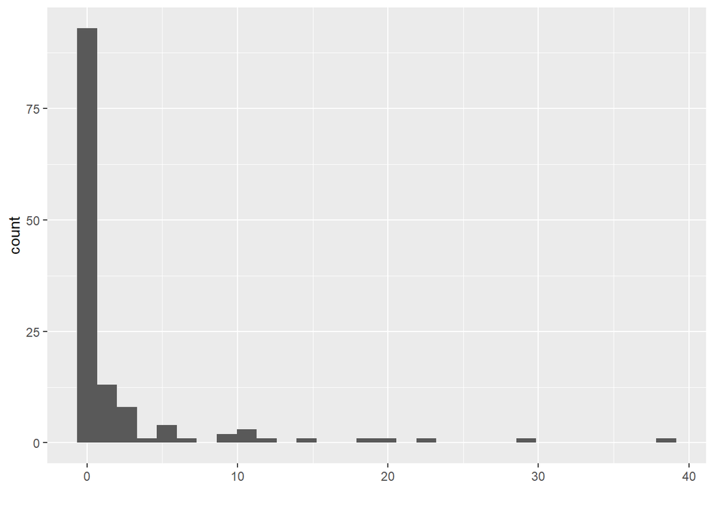

```r
x_df<-na.omit(wb%>%filter(Year==2015,Indicator.Name=="Oil rents (% of GDP)")%>%dplyr::select(value))
ggplot(data=x_df,aes(x_df$value))+geom_histogram()+xlab('')
```

По гистограмме видно, что распределение показателя не соответсвует нормальному распределению

Для привода распределение показателя к нормальному(логнормальному) распределению можно трансформировать натуральные показатели к логарифмическим

```r
ln_x<-log(na.omit(wb%>%filter(Year==2015,Indicator.Name=="Oil rents (% of GDP)")%>%select(value))$value)
```

Основные статистические показатели

```r
summary(ln_x)
```

```
##    Min. 1st Qu.  Median    Mean 3rd Qu.    Max.
##    -Inf    -Inf -2.8044    -Inf  0.2771  3.6502
```

Найдем интервальную оценку для математического распределения с помощью распределения Стьюдента, с доверитеьным интервалом 95%

```r
alpha<-0.05
error <- qt(1-alpha/2,df=length(ln_x)-1)*sd(ln_x)/sqrt(length(ln_x))
mean(ln_x)-error
```

```
## [1] NaN
```

```r
mean(ln_x)+error
```

```
## [1] NaN
```

```r
t.test
```

```
## function (x, ...)
## UseMethod("t.test")
## <bytecode: 0x0663b374>
## <environment: namespace:stats>
```

Найдем интервальную оценку для дисперсии с 95% верояностью(используем $\chi^2$ распределение)

```r
df=length(ln_x)
chilower = qchisq((alpha/2), df)
chiupper = qchisq(alpha/2, df,lower.tail = FALSE)
#chiupper<-qchisq((1-alpha/2), df)
df*var(ln_x)/chiupper
```

```
## [1] NaN
```

Оценим коэффициенты асимметрии

```r
skewness(ln_x)
```

```
## [1] NaN
```

И эксцесса

```r
kurtosis(ln_x)
```

```
## [1] NaN
```

Проведем тесты

```r
pearson.test(x) # Тест Пирсона
```

```
##
##  Pearson chi-square normality test
##
## data:  x
## P = 903, p-value < 2.2e-16
```

```r
ad.test(x) # Тест Андерсона-Дарлинга
```

```
##
##  Anderson-Darling normality test
##
## data:  x
## A = 27.866, p-value < 2.2e-16
```

```r
shapiro.test(ln_x) # Тест Шапиро-Вилка
```

```
##
##  Shapiro-Wilk normality test
##
## data:  ln_x
## W = NaN, p-value = NA
```

Построим гистограмму распредления трансформированных значений

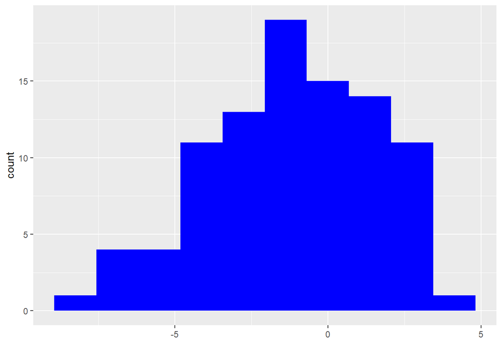

```r
x_df<-na.omit(wb%>%filter(Year==2015,Indicator.Name=="Oil rents (% of GDP)")%>%select(value))
x_df$value<-log(x_df$value)
ggplot(data=x_df,aes(x_df$value))+geom_histogram(fill='blue',bins=10)+xlab('')
```

По гистограмме мы видим, что распределение соответствует нормальному распределению

8. Для окончательной проверки соответсвтвия параметров (доходов от продажи нефти (в % от ВВП)) параметрам нормального распределения.

Сгенирируем случайненые нормальные величины с параметрами (доходов от продажи нефти (в % от ВВП)), и проведем тесты на соответствие параметров нобора сгенирированных случайных величин, параметрам нормального распределения

```r
y<-rnorm(length(ln_x),mean(ln_x),sd(ln_x))
```

```r
pearson.test(x) # Тест Пирсона
```

```
##
##  Pearson chi-square normality test
##
## data:  x
## P = 903, p-value < 2.2e-16
```

```r
ad.test(x) # Тест Андерсона-Дарлинга
```

```
##
##  Anderson-Darling normality test
##
## data:  x
## A = 27.866, p-value < 2.2e-16
```

```r
# hist(y,main='Гистограмма биномиального закона распределения', ylab = 'Частота',breaks = "Sturges")
```

Для сравнения сгенерируем случайную величину, распределенную по закону Пуассона (1000 наблюений, вероятность события 0.01)

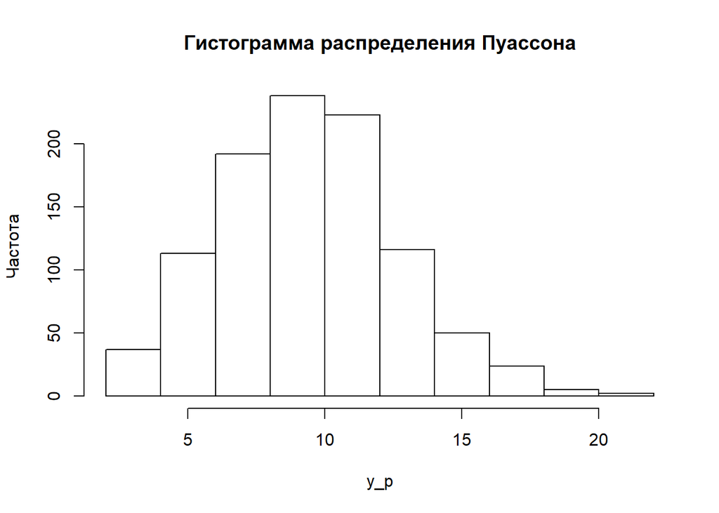

```r
y_p<-rpois(1000,1000*.01)
hist(y_p,main='Гистограмма распределения Пуассона',ylab = 'Частота')
```

Также построим гистограмму с биномиальным законом распределения

```r
y_b<-rbinom(100,5,0.4)
y_b
```

```
##   [1] 1 3 3 3 4 4 2 1 4 2 2 1 2 1 2 5 3 2 1 0 2 1 2 4 2 2 2 1 2 4 2 2 2 1 1
##  [36] 2 1 4 3 2 2 1 4 1 1 1 1 3 2 3 2 3 1 3 2 1 1 3 1 2 2 3 3 2 1 2 5 1 3 3
##  [71] 1 1 2 3 1 2 2 1 4 0 2 2 1 2 1 2 3 0 2 2 0 2 2 3 2 3 1 1 0 4
```

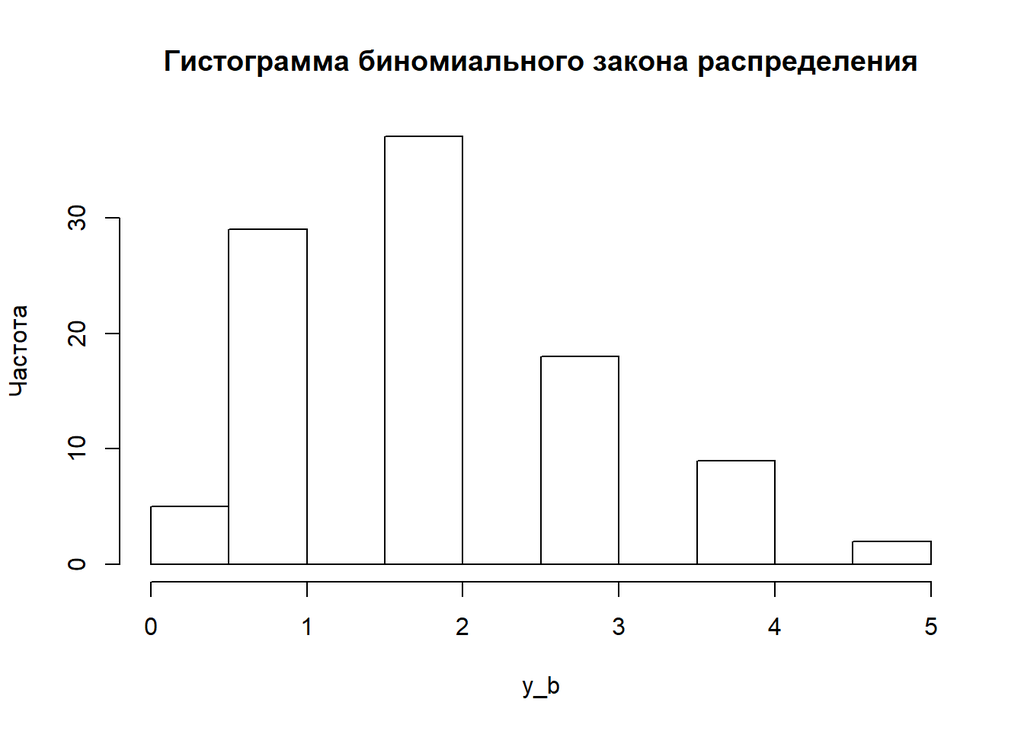

```r
hist(y_b,main='Гистограмма биномиального закона распределения',ylab = 'Частота')
```

9. Проведм анализ фондового индекса

Загрузим данные фондового индекса SP500

```r
sp500<-read.csv(paste(dir,'^GSPC.csv',sep=''),stringsAsFactors = FALSE)
```

Переведем столбец с датой из текстового формата в формат даты

```r
sp500$Date<-as.Date(sp500$Date)
class(sp500$Date)
```

```
## [1] "Date"
```

```r
head(sp500)
```

```
##         Date  Open  High   Low Close Adj.Close  Volume
## 1 1960-10-31 53.39 53.39 53.39 53.39     53.39 2460000
## 2 1960-11-01 53.94 53.94 53.94 53.94     53.94 2600000
## 3 1960-11-02 54.22 54.22 54.22 54.22     54.22 2780000
## 4 1960-11-03 54.43 54.43 54.43 54.43     54.43 2580000
## 5 1960-11-04 54.90 54.90 54.90 54.90     54.90 3050000
## 6 1960-11-07 55.11 55.11 55.11 55.11     55.11 3540000
```

Сократим срок наблюдение с 1 января 200г.

```r
sp500<-sp500[sp500$Date>'1999-12-31',]
head(sp500)
```

```
##            Date    Open    High     Low   Close Adj.Close     Volume
## 9862 2000-01-03 1469.25 1478.00 1438.36 1455.22   1455.22  931800000
## 9863 2000-01-04 1455.22 1455.22 1397.43 1399.42   1399.42 1009000000
## 9864 2000-01-05 1399.42 1413.27 1377.68 1402.11   1402.11 1085500000
## 9865 2000-01-06 1402.11 1411.90 1392.10 1403.45   1403.45 1092300000
## 9866 2000-01-07 1403.45 1441.47 1400.73 1441.47   1441.47 1225200000
## 9867 2000-01-10 1441.47 1464.36 1441.47 1457.60   1457.60 1064800000
```

Построим график для SP500

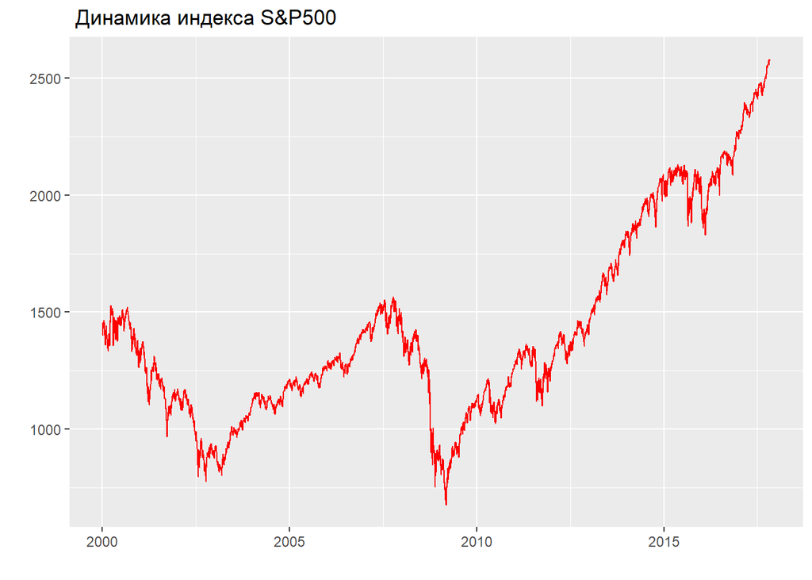

```r
ggplot(data=sp500,aes(Date,Adj.Close))+geom_line(color='red')+xlab('')+ylab(' ')+ggtitle(' Динамика индекса S&P500')
```

По графику видно, что SP500 преимущественно рос, особенно сильный рост заметен с 2009г.

Трансформируем данные в логарифм(дневные доходности)

```r
sp500_ln<-data.frame(Date=sp500$Date[-1],sp_ln=diff(log(sp500$Adj.Close),1))
head(sp500_ln)
```

```
##         Date         sp_ln
## 1 2000-01-04 -0.0390991755
## 2 2000-01-05  0.0019203377
## 3 2000-01-06  0.0009552219
## 4 2000-01-07  0.0267299501
## 5 2000-01-10  0.0111278250
## 6 2000-01-11 -0.0131485768
```

```r
tail(sp500_ln)
```

```
##            Date        sp_ln
## 4480 2017-10-23 -0.003980396
## 4481 2017-10-24  0.001616601
## 4482 2017-10-25 -0.004673956
## 4483 2017-10-26  0.001270139
## 4484 2017-10-27  0.008040610
## 4485 2017-10-30 -0.003197577
```

Просмотрем основные параметры распределения SP500_ln

```r
summary(sp500_ln)
```

```
##       Date                sp_ln
##  Min.   :2000-01-04   Min.   :-0.0946951
##  1st Qu.:2004-06-23   1st Qu.:-0.0048951
##  Median :2008-12-03   Median : 0.0005059
##  Mean   :2008-12-03   Mean   : 0.0001271
##  3rd Qu.:2013-05-20   3rd Qu.: 0.0056711
##  Max.   :2017-10-30   Max.   : 0.1095720
```

Среднее значение показывает, что основная доходность индекса за 17 лет соответствовала 0.01%

Найдем стандартное отклонение SP500_ln

```r
sd(sp500_ln$sp_ln)
```

```
## [1] 0.0121923
```

Стандартное отколенение незначительное (0.01)

Найдем коэффициенты асимметрии и эксцеса

```r
skewness(sp500_ln$sp_ln)
```

```
## [1] -0.2035829
```

```r
kurtosis(sp500_ln$sp_ln)
```

```
## [1] 11.57697
```

Коэффициенты показываюн незначительную асимметрию, но достаточно значительный эксцесс. Из этого следует, что медиана лежит достаточно близко к среднему значениию, и что распределение сильно вытянута вверх

Проведем тесты на соответствие параметров выборки параметрам нормального распределения

```r
pearson.test(sp500_ln$sp_ln)
```

```
##
##  Pearson chi-square normality test
##
## data:  sp500_ln$sp_ln
## P = 784.82, p-value < 2.2e-16
```

```r
shapiro.test(sp500_ln$sp_ln)
```

```
##
##  Shapiro-Wilk normality test
##
## data:  sp500_ln$sp_ln
## W = 0.90959, p-value < 2.2e-16
```

p-value<2.2e-16 тестов показывает, что нулевая гипотеза(Н0) о том, что распределение соответствует нормальному распределению отвергается

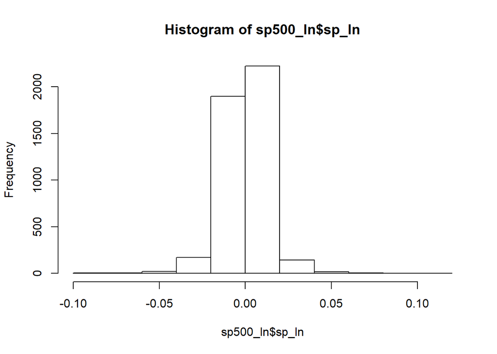

```r
hist(sp500_ln$sp_ln)
```

На данной гистограме отчетливо видене достаточно большой эксцесс

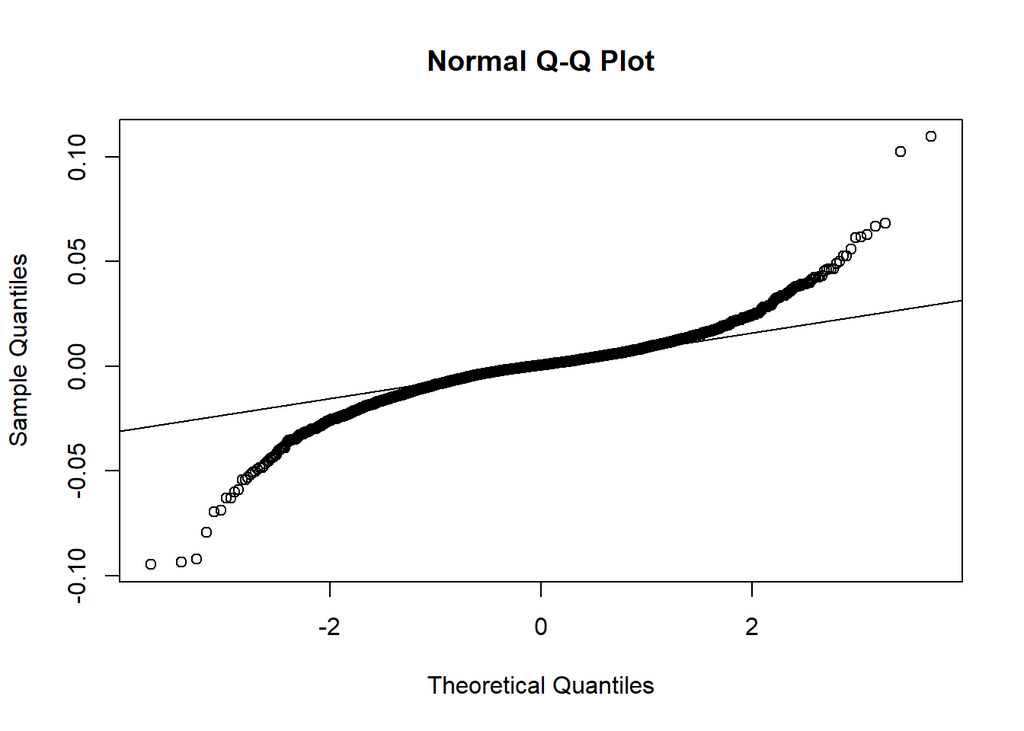

```r
qqnorm(sp500_ln$sp_ln)
qqline(sp500_ln$sp_ln)
```

На графике видно, что значительная часть данных лежит в обасти нормального распределения